# Violating Linear Model Assumptions

### Fitting a linear model

**Linear model**

\( y_i = \beta_0 + \beta_1 X_1 + \epsilon_i \)

\( \epsilon_i \sim \mathcal{N}(\mu, \sigma) \)

**Minimize residuals**

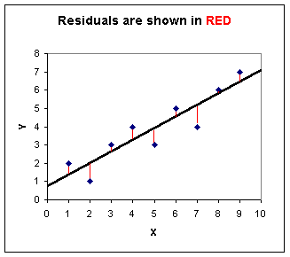

http://mtweb.mtsu.edu/stats/dictionary/formula.htm

### Review: Model assumptions

What are our linear model assumptions?

### Review: Model assumptions

- Linearity
- Homogeneity of variance (Homoscedasticity)
- Normally distributed error
- Minimal multicollinearity (if multiple \( X \))
- Independence of observations (no autocorrelation)

### Violating assumptions in ecology

In population biology and ecology, violating these rules is more of a rule than an exception.

What we do depends on the assumption.

### Normality

Possibly of least concern. Given a large sample size, models are often robust to modest violations of normality.

However, we don't always have large samples sizes in ecological data sets.

### Other violations

- Linearity - will likely result in issues of homogeneity. Means your model doesn't fit and you should develop a different deterministic model
- Homogeneity - small variation is okay but otherwise a major problem. Can transform the data or make different distributional assumptions
- Multicollinearity - only a problem at high values, partially an estimation problem, partly a problem of inference. Can also bias parameter uncertainty
- Independence - The most serious problem. Can alter the model (model the residuals), transform, or group the data to address these issues.

### Case Study 1: Wedge Clam Data

Biomass of 398 wedge clams. Explore the data with a scatterplot matrix.

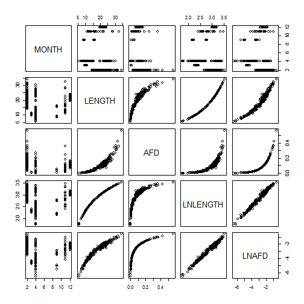

*Examples from Zuur et al. 2009*

### Case Study 1: Wedge Clam Data

Model AFD ~ f(Log(Length) + Month); where month is a group (factor)

\( AFD_i = \beta_0 + \beta_1 LNLENGTH_i + \beta fMONTH_i + \epsilon_i \)

### Case Study 1: Wedge Clam Data

Check Assumptions

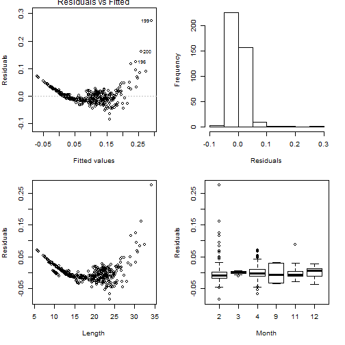

### Case Study 1: Wedge Clam Data

**Make it linear with a log transformation**

Model log(AFD) ~ f(Log(Length) + Month); where month is a group (factor)

\( LNAFD_i = \beta_0 + \beta_1 LNLENGTH_i + \beta fMONTH_i + \epsilon_i \)

### Case Study 1: Wedge Clam Data

**Check Assumptions**

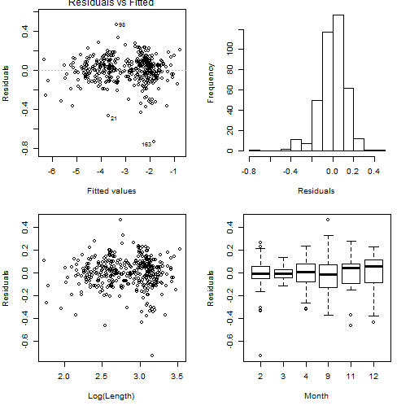

Better. Linear but still a problem of heterogeneity with Month. (solution is to allow variance to vary by month)

### Case Study 2: Moby's Teeth

Isotope ratios in teeth of standed whales. We expect \( \delta^{15}N \) to increase with age.

\( y_i = 11.7 + 0.113 x age_i + \epsilon_i \)

\( \sigma = 0.485 \)

89% of the variance explained by the model

```
Call:
lm(formula = X15N ~ Age, data = teeth, subset = (teeth$Tooth ==
    "Moby"))

Residuals:
     Min       1Q   Median       3Q      Max
-1.07102 -0.28706  0.04346  0.33820  1.13724

Coefficients:
             Estimate Std. Error t value Pr(>|t|)
(Intercept) 11.748940   0.163559   71.83   <2e-16 ***
Age          0.113794   0.006186   18.40   <2e-16 ***
---
Signif. codes:  0 '***' 0.001 '**' 0.01 '*' 0.05 '.' 0.1 ' ' 1

Residual standard error: 0.4859 on 40 degrees of freedom
Multiple R-squared:  0.8943,    Adjusted R-squared:  0.8917
F-statistic: 338.4 on 1 and 40 DF,  p-value: < 2.2e-16
```

### Case Study 2: Moby's Teeth

**Check assumptions**

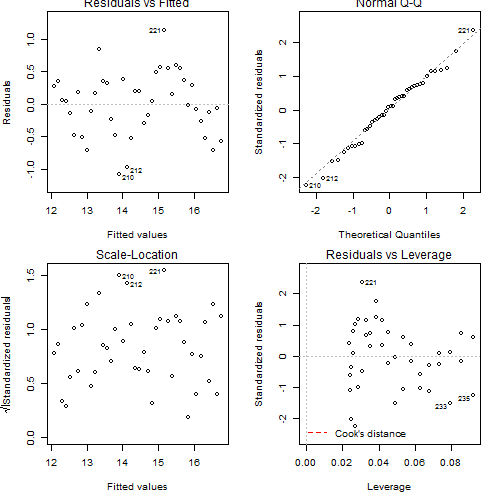

Violation of independence. We shouldn't draw inference from the model. Solution will be to model the variance, likely with an autoregressive (AR1) function.